# Assignment 2: Electricity Market Prices

In this document, Market Clearing Price (PTF) - System Marginal Price (SMF) data shared on EPİAŞ Reporting Page is used. In addition to these two data, there are Positive Unbalance Price and Negative Unbalance Price data in the raw data.

**Market Clearing Price (PTF):**It can be called the price that occurs at the intersection of supply and demand as a result of bids made in the day ahead market.

**System Marginal Price (SMF):** In cases where the system shows an energy deficit or excess, it can be called the bid price corresponding to the net order volume.

**Positive Unbalance Price (PDF):** When there is an excess of energy in the system, it can be considered as the price value that enables the energy to be extracted cheaper than normal.

**Negative Unbalance Price (NDF):** When there is an energy deficit in the system, it can be considered as the price value that enables energy to be bought more expensive than normal.

For more detailed information, you can visit the [EPİAŞ](https://www.epias.com.tr/spot-elektrik-piyasasi) website.

> Contents of raw data:

```r
ptfsmf %>% glimpse()
```

```
## Rows: 744
## Columns: 6
## $ Tarih                               <chr> "01.07.20 00:00", "01.07.20 01:...
## $ PTF                                 <dbl> 323.85, 326.95, 324.31, 322.11,...
## $ SMF                                 <dbl> 211.00, 201.00, 211.00, 211.00,...
## $ Pozitif.Dengesizlik.Fiyati..TL.MWh. <dbl> 204.67, 194.97, 204.67, 204.67,...
## $ Negatif.Dengesizlik.Fiyati..TL.MWh. <dbl> 333.57, 336.76, 334.04, 331.77,...
## $ SMF.Yon                             <chr> "Enerji Fazlasi", "Enerji Fazla...
```

> The data:

EPIAS General Data

| Tarih | PTF | SMF | Pozitif.Dengesizlik.Fiyati..TL.MWh. | Negatif.Dengesizlik.Fiyati..TL.MWh. | SMF.Yon |
| --- | --- | --- | --- | --- | --- |
| 01.07.20 00:00 | 323.85 | 211.00 | 204.67 | 333.57 | Enerji Fazlasi |
| 01.07.20 01:00 | 326.95 | 201.00 | 194.97 | 336.76 | Enerji Fazlasi |
| 01.07.20 02:00 | 324.31 | 211.00 | 204.67 | 334.04 | Enerji Fazlasi |
| 01.07.20 03:00 | 322.11 | 211.00 | 204.67 | 331.77 | Enerji Fazlasi |
| 01.07.20 04:00 | 320.00 | 201.00 | 194.97 | 329.60 | Enerji Fazlasi |
| 01.07.20 05:00 | 286.21 | 181.00 | 175.57 | 294.80 | Enerji Fazlasi |
| 01.07.20 06:00 | 210.13 | 113.75 | 110.34 | 216.43 | Enerji Fazlasi |
| 01.07.20 07:00 | 318.20 | 201.00 | 194.97 | 327.75 | Enerji Fazlasi |
| 01.07.20 08:00 | 324.85 | 181.00 | 175.57 | 334.60 | Enerji Fazlasi |
| 01.07.20 09:00 | 327.67 | 181.00 | 175.57 | 337.50 | Enerji Fazlasi |
| 01.07.20 10:00 | 329.60 | 250.00 | 242.50 | 339.49 | Enerji Fazlasi |
| 01.07.20 11:00 | 329.99 | 329.99 | 320.09 | 339.89 | Enerji Acigi |
| 01.07.20 12:00 | 324.21 | 342.80 | 314.48 | 353.08 | Enerji Acigi |
| 01.07.20 13:00 | 327.83 | 355.83 | 318.00 | 366.50 | Enerji Acigi |
| 01.07.20 14:00 | 332.37 | 377.37 | 322.40 | 388.69 | Enerji Acigi |
| 01.07.20 15:00 | 331.29 | 376.29 | 321.35 | 387.58 | Enerji Acigi |
| 01.07.20 16:00 | 331.14 | 375.00 | 321.21 | 386.25 | Enerji Acigi |
| 01.07.20 17:00 | 330.81 | 360.81 | 320.89 | 371.63 | Enerji Acigi |
| 01.07.20 18:00 | 327.06 | 351.46 | 317.25 | 362.00 | Enerji Acigi |
| 01.07.20 19:00 | 325.04 | 342.80 | 315.29 | 353.08 | Enerji Acigi |
| 01.07.20 20:00 | 329.11 | 250.00 | 242.50 | 338.98 | Enerji Fazlasi |
| 01.07.20 21:00 | 329.95 | 280.00 | 271.60 | 339.85 | Enerji Fazlasi |
| 01.07.20 22:00 | 327.72 | 282.72 | 274.24 | 337.55 | Enerji Fazlasi |
| 01.07.20 23:00 | 322.85 | 273.00 | 264.81 | 332.54 | Enerji Fazlasi |
| 02.07.20 00:00 | 300.26 | 310.26 | 291.25 | 319.57 | Enerji Acigi |
| 02.07.20 01:00 | 302.94 | 310.00 | 293.85 | 319.30 | Enerji Acigi |
| 02.07.20 02:00 | 300.46 | 301.00 | 291.45 | 310.03 | Enerji Acigi |
| 02.07.20 03:00 | 199.33 | 234.33 | 193.35 | 241.36 | Enerji Acigi |
| 02.07.20 04:00 | 268.88 | 298.88 | 260.81 | 307.85 | Enerji Acigi |
| 02.07.20 05:00 | 223.99 | 253.99 | 217.27 | 261.61 | Enerji Acigi |

[output cut: 714 more lines]

> Editing the Data

The first step, “Dates” column is char format, so this is converted, and also other columns converted to right format.

```r
ptfsmf$Tarih <- gsub(pattern = "\\.","-",ptfsmf$Tarih)
ptfsmf$Tarih <- as.POSIXct(ptfsmf$Tarih, format="%d.%m.%y %H:%M")
```

Column names are updated, to easily understand.

```r
colnames(ptfsmf)[1] = "Tarih"
colnames(ptfsmf)[2] = "PTF"
colnames(ptfsmf)[3] = "SMF"
colnames(ptfsmf)[4] = "Positive.Imbalanca.Price"
colnames(ptfsmf)[5] = "Negative.Imbalance.Price"
colnames(ptfsmf)[6] = "SMF.Direction"
data_frame <-ptfsmf %>% transmute(Tarih, PTF, SMF, Positive.Imbalanca.Price, Negative.Imbalance.Price, SMF.Direction)
```

> Data Analysis with dplyr and ggplot

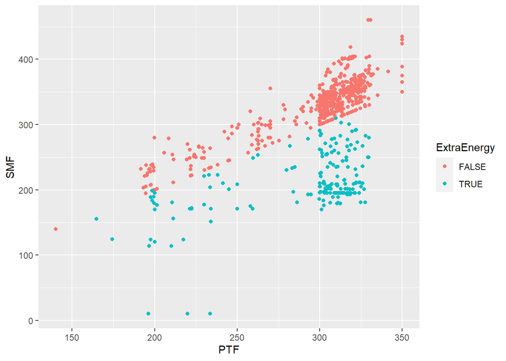

```r
ptfsmf %>% mutate(ExtraEnergy = PTF>SMF)%>% ggplot()+geom_point(aes(x=PTF, y=SMF, color = ExtraEnergy))
```

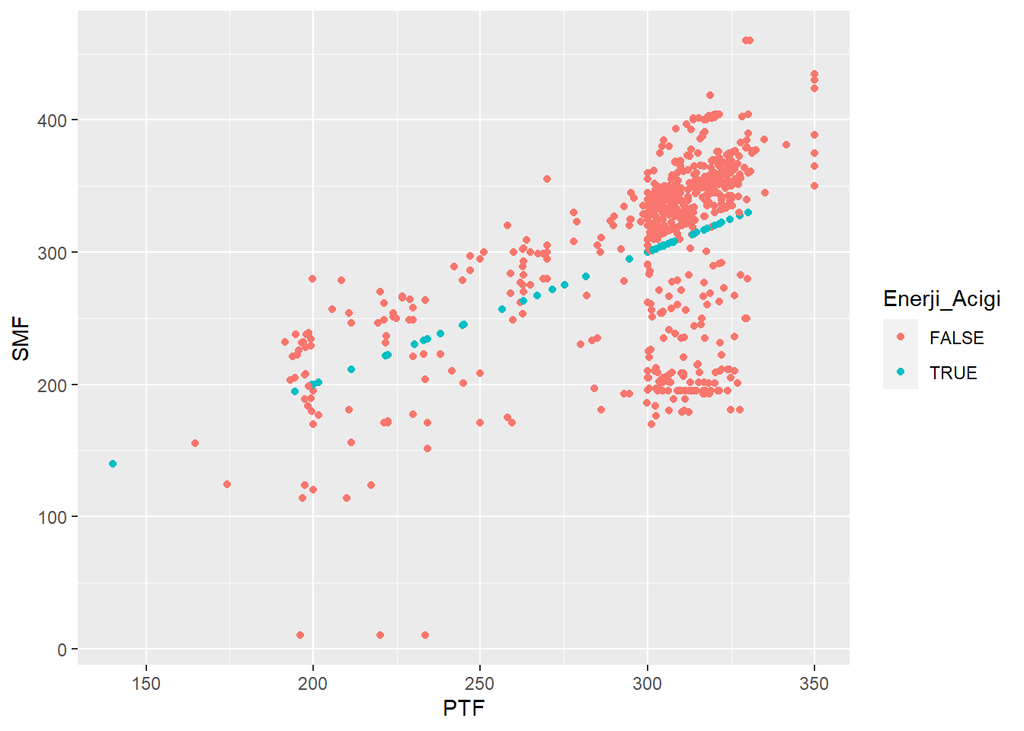

```r
ptfsmf %>% mutate(Enerji_Acigi = PTF==SMF)%>% ggplot()+geom_point(aes(x=PTF, y=SMF, color = Enerji_Acigi))
```

```
## # A tibble: 1 x 2
##     Day AvgPTF
##   <int>  <dbl>
## 1    NA   296.
```

[output not shown]

[output cut: 730 more lines]

```
## # A tibble: 1 x 2
##     Day AvgSMF
##   <int>  <dbl>
## 1    NA   299.
```

[figure not shown]